# Supervised Learning and Visualization Practical 5

Daniel Anadria

16 October 2022

**Practical 5: Classification 1**

```r
# load libraries
library(MASS)
library(class)
library(ISLR)
library(tidyverse)
```

```r
set.seed(45)
```

1. Create a scatterplot of the Default dataset, where balance is mapped to the x position, income is mapped to the y position, and default is mapped to the colour. Can you see any interesting patterns already?

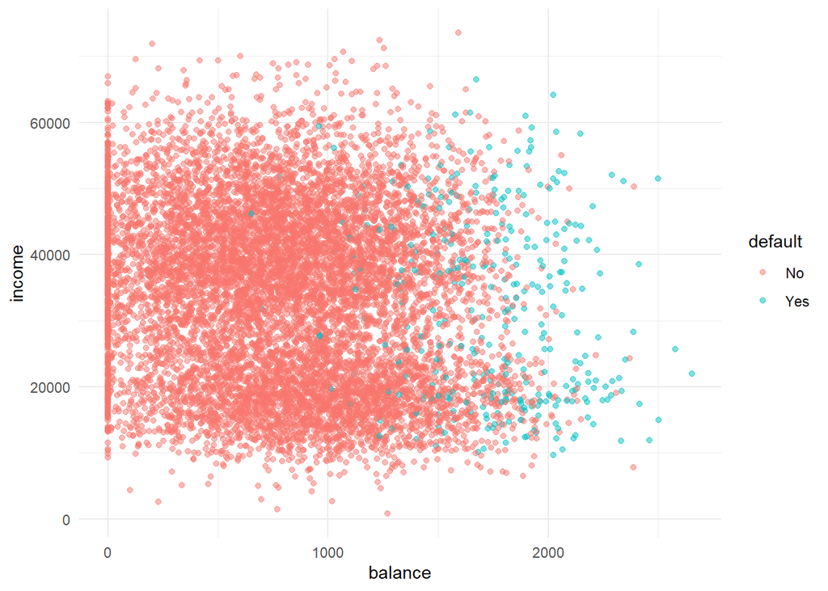

```r
p1 <- ggplot(Default, aes(x = balance, y = income, color = default))+
  geom_point(alpha = 0.5)+
  theme_minimal()
p1
```

We see that the vast majority did not default on payment. And that those who did default tended to have higher balance, but same income.

2. Add facet_grid(cols = vars(student)) to the plot. What do you see?

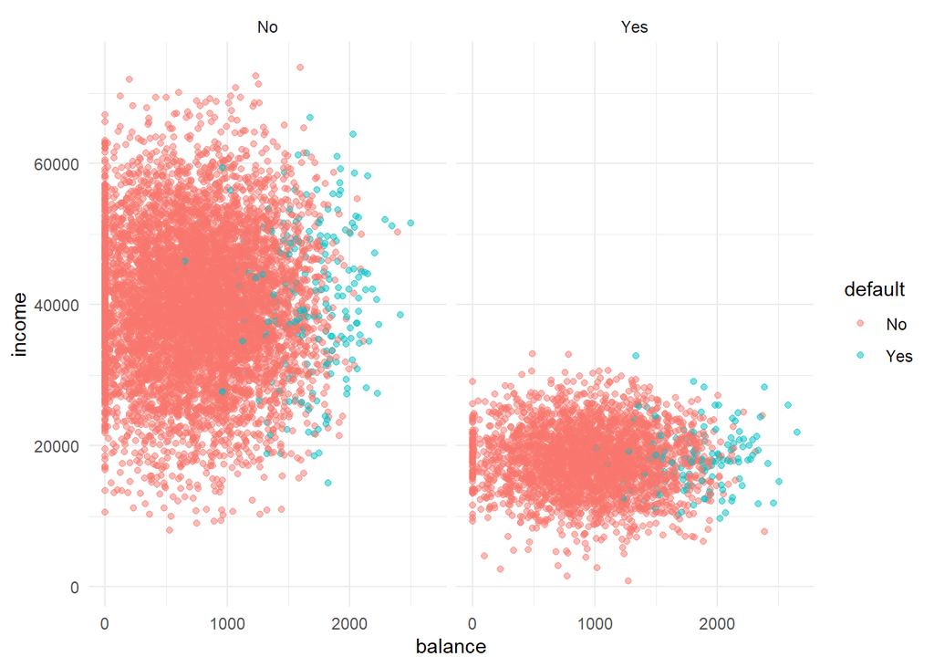

```r
p1 + facet_grid(cols = vars(student))
```

We see that students tend to have lower income than non-students. It seems that the probability of defaulting is still the same, and there for those with higher balance, regardless of their student status.

3. Transform “student” into a dummy variable using ifelse() (0 = not a student, 1 = student). Then, randomly split the Default dataset into a training set default_train (80%) and a test set default_test (20%)

```r
# mutate student into 0,1
default <- Default %>% mutate(student = ifelse(student == "Yes", 1, 0))

# randomize default
default <- default[sample(1:nrow(default)), ]

# train-test split
## indexes for train and test
train_idx <- seq(1,nrow(default)*0.8)
test_idx <- seq(max(train_idx)+1, nrow(default))
## train and test data
default_train <- default[train_idx,]
default_test <- default[test_idx,]
```

# K-Nearest Neighbors

4. Create class predictions for the test set using the knn() function. Use student, balance, and income (but no basis functions of those variables) in the default_train dataset. Set k to 5. Store the predictions in a variable called knn_5_pred.

```r
knn_5_pred <- class::knn(
  train = default_train[,-1],
  test = default_test[,-1],
  cl = as.factor(default_train$default),
  k = 5)
head(knn_5_pred)
```

```
## [1] No No No No No No
## Levels: No Yes
```

5. Create two scatter plots with income and balance as in the first plot you made. One with the true class (default) mapped to the colour aesthetic, and one with the predicted class (knn_5_pred) mapped to the colour aesthetic.

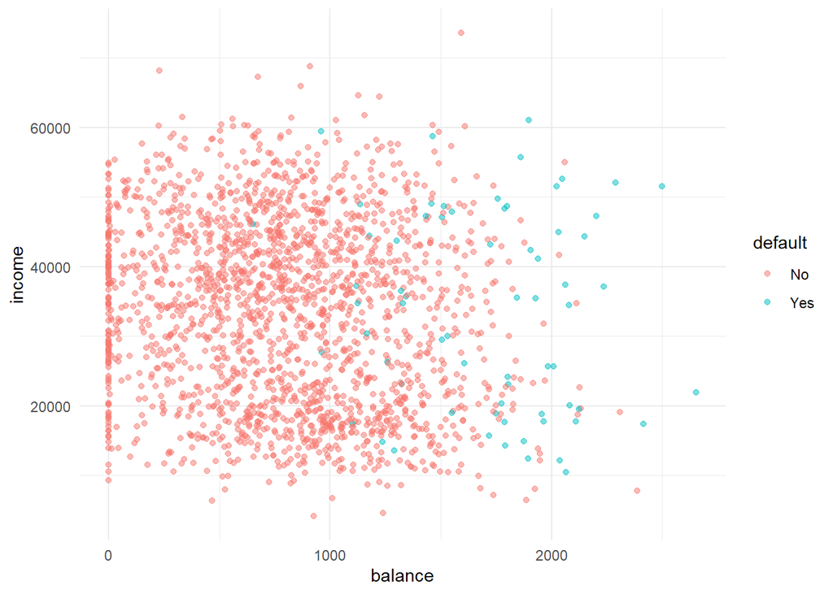

```r
# attach predicted values to train
default_test$predicted <- knn_5_pred

# true default value
p3 <- ggplot(default_test, aes(x = balance, y = income, color = default))+
  geom_point(alpha = 0.5)+
  theme_minimal()
p3
```

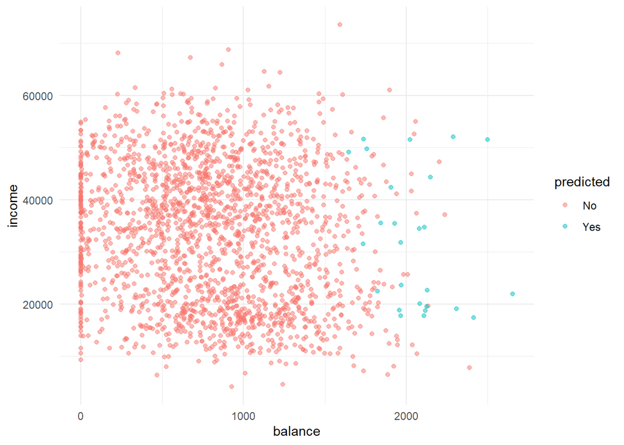

```r
# predicted default value

p4 <- ggplot(default_test, aes(x = balance, y = income, color = predicted))+
  geom_point(alpha = 0.5)+
  theme_minimal()
p4
```

6. Repeat the same steps, but now with a knn_2_pred vector generated from a 2-nearest neighbours algorithm. Are there any differences?

```r
knn_2_pred <- class::knn(
  train = default_train[,-c(1,5)],
  test = default_test[,-c(1,5)],
  cl = as.factor(default_train$default),
  k = 2)
```

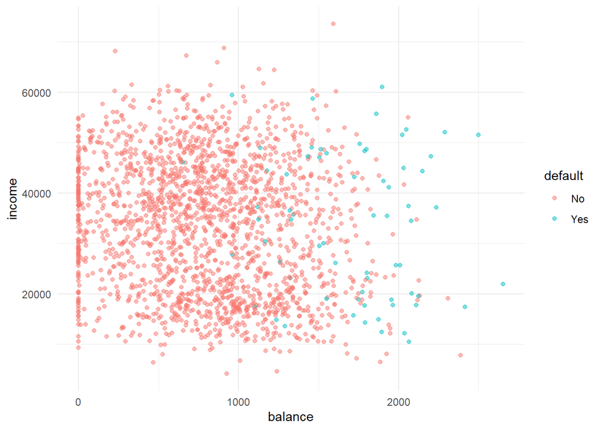

```r
# attach predicted values to train
default_test$predicted <- knn_2_pred

# true default value
p5 <- ggplot(default_test, aes(x = balance, y = income, color = default))+
  geom_point(alpha = 0.5)+
  theme_minimal()
p5
```

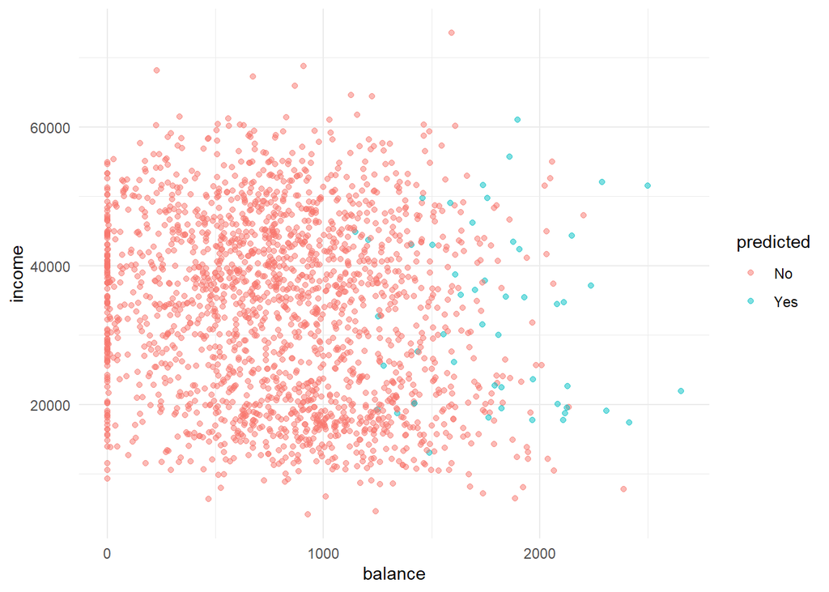

```r
# predicted default value

p6 <- ggplot(default_test, aes(x = balance, y = income, color = predicted))+
  geom_point(alpha = 0.5)+
  theme_minimal()
p6
```

It seems like the predictions with k=2 is close to predictions with k=5. However, k=2 captures more people in the mid-range of balance, which might be favorable.

```r
# remove predict from default_test
default_test <- default_test
```